# R Notebook

**Principles of Data Visualization and Introduction to ggplot2**

I have provided you with data about the 5,000 fastest growing companies in the US, as compiled by Inc. magazine. lets read this in:

```r
inc <- read.csv("https://raw.githubusercontent.com/charleyferrari/CUNY_DATA_608/master/module1/Data/inc5000_data.csv", header= TRUE)
```

And lets preview this data:

```r
head(inc)
```

```
##   Rank                         Name Growth_Rate   Revenue
## 1    1                         Fuhu      421.48 1.179e+08
## 2    2        FederalConference.com      248.31 4.960e+07
## 3    3                The HCI Group      245.45 2.550e+07
## 4    4                      Bridger      233.08 1.900e+09
## 5    5                       DataXu      213.37 8.700e+07
## 6    6 MileStone Community Builders      179.38 4.570e+07
##                       Industry Employees         City State
## 1 Consumer Products & Services       104   El Segundo    CA
## 2          Government Services        51     Dumfries    VA
## 3                       Health       132 Jacksonville    FL
## 4                       Energy        50      Addison    TX
## 5      Advertising & Marketing       220       Boston    MA
## 6                  Real Estate        63       Austin    TX
```

```r
summary(inc)
```

```
##       Rank                          Name       Growth_Rate
##  Min.   :   1   (Add)ventures         :   1   Min.   :  0.340
##  1st Qu.:1252   @Properties           :   1   1st Qu.:  0.770
##  Median :2502   1-Stop Translation USA:   1   Median :  1.420
##  Mean   :2502   110 Consulting        :   1   Mean   :  4.612
##  3rd Qu.:3751   11thStreetCoffee.com  :   1   3rd Qu.:  3.290
##  Max.   :5000   123 Exteriors         :   1   Max.   :421.480
##                 (Other)               :4995
##     Revenue                                  Industry      Employees
##  Min.   :2.000e+06   IT Services                 : 733   Min.   :    1.0
##  1st Qu.:5.100e+06   Business Products & Services: 482   1st Qu.:   25.0
##  Median :1.090e+07   Advertising & Marketing     : 471   Median :   53.0
##  Mean   :4.822e+07   Health                      : 355   Mean   :  232.7
##  3rd Qu.:2.860e+07   Software                    : 342   3rd Qu.:  132.0
##  Max.   :1.010e+10   Financial Services          : 260   Max.   :66803.0
##                      (Other)                     :2358   NA's   :12
##             City          State
##  New York     : 160   CA     : 701
##  Chicago      :  90   TX     : 387
##  Austin       :  88   NY     : 311
##  Houston      :  76   VA     : 283
##  San Francisco:  75   FL     : 282
##  Atlanta      :  74   IL     : 273
##  (Other)      :4438   (Other):2764
```

Think a bit on what these summaries mean. Use the space below to add some more relevant non-visual exploratory information you think helps you understand this data:

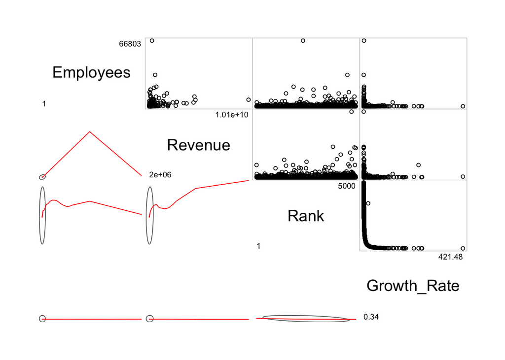

```r
# compare variables to one another

library(corrgram)
corrgram(inc, order=TRUE, lower.panel=panel.ellipse,
  upper.panel=panel.pts, text.panel=panel.txt,
  diag.panel=panel.minmax)
```

From the above, there appears to be a slight relationship between employees and revenue. I will explore that relationship further below:

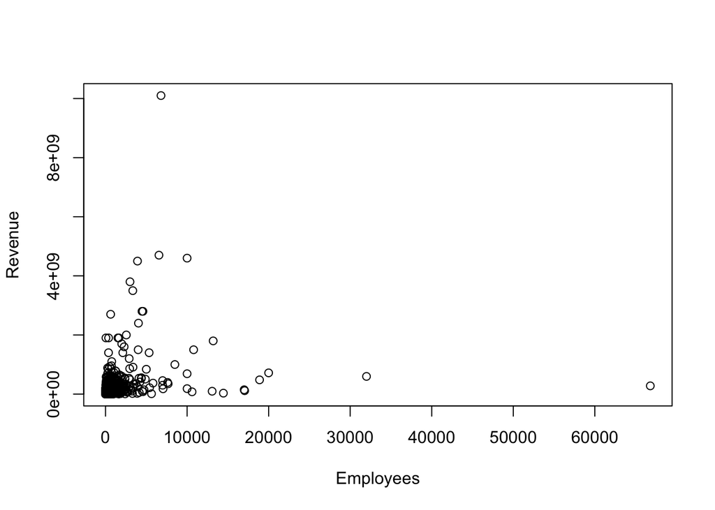

```r
# compare employees to revenue
library(ggplot2)
plot(inc$Employees, inc$Revenue, xlab = "Employees", ylab = "Revenue")
```

```r
cor(inc$Employees, inc$Revenue, use = "complete.obs")
```

```
## [1] 0.2779332
```

As we can see, the correlation is very weak.

## Question 1

Create a graph that shows the distribution of companies in the dataset by State (ie how many are in each state). There are a lot of States, so consider which axis you should use. This visualization is ultimately going to be consumed on a ‘portrait’ oriented screen (ie taller than wide), which should further guide your layout choices.

```r
# Answer Question 1 here
#load proper packages
library(dplyr)
#group states and count number in groups
states <- inc %>%
  group_by(State) %>%
  count(State)

head(states)
```

```
## # A tibble: 6 x 2
## # Groups:   State [6]
##   State     n
##   <fct> <int>
## 1 AK        2
## 2 AL       51
## 3 AR        9
## 4 AZ      100
## 5 CA      701
## 6 CO      134
```

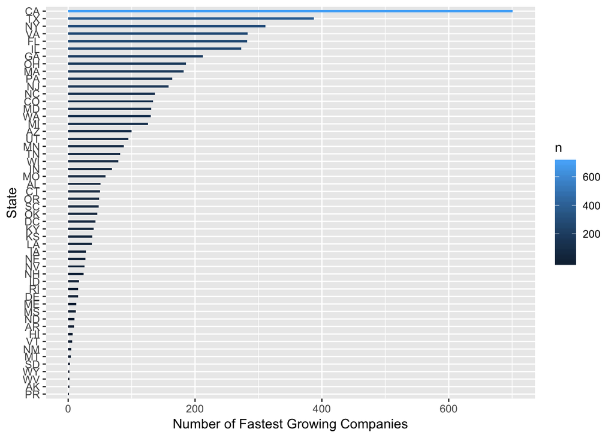

```r
#load packages
library(ggplot2)

#create ggplot object
x <- ggplot(states, aes(x=reorder(State, n), y=n, fill=n))

#create bar plot
x + geom_bar(stat="identity", width=0.3, position = position_dodge(width=.5)) + coord_flip() + labs(x = "State", y = "Number of Fastest Growing Companies")
```

California has the most fast growing companies. This is probably due to the tech boom in Silicon Valley. It would be interesting to compare each states fastest growing companies by industry and see which industry dominates which states and if tech companies are doing better in certain states. This info would be helpful to people starting a company, to see where they should be located to start that company.

## Quesiton 2

Lets dig in on the state with the 3rd most companies in the data set. Imagine you work for the state and are interested in how many people are employed by companies in different industries. Create a plot that shows the average and/or median employment by industry for companies in this state (only use cases with full data, use R’s `complete.cases()` function.) In addition to this, your graph should show how variable the ranges are, and you should deal with outliers.

```r
# Answer Question 2 here
head(arrange(states, desc(n)))
```

```
## # A tibble: 6 x 2
## # Groups:   State [6]
##   State     n
##   <fct> <int>
## 1 CA      701
## 2 TX      387
## 3 NY      311
## 4 VA      283
## 5 FL      282
## 6 IL      273
```

```r
#select only cases with full data
inc <- inc[complete.cases(inc),]

#select only NY companies
ny = inc %>%
  filter(State == "NY")

#check for outliers
head(arrange(ny, desc(Employees)))
```

```
##   Rank                       Name Growth_Rate   Revenue
## 1 4577 Sutherland Global Services        0.48 5.976e+08
## 2 4936                       Coty        0.36 4.600e+09
## 3 4716              Westcon Group        0.44 3.800e+09
## 4 3899  Denihan Hospitality Group        0.71 2.808e+08
## 5 4363               TransPerfect        0.55 3.413e+08
## 6 1499       Sterling Infosystems        2.66 2.149e+08
##                       Industry Employees      City State
## 1 Business Products & Services     32000 Pittsford    NY
## 2 Consumer Products & Services     10000  New York    NY
## 3                  IT Services      3000 Tarrytown    NY
## 4         Travel & Hospitality      2280  New York    NY
## 5 Business Products & Services      2218  New York    NY
## 6              Human Resources      2081  New York    NY
```

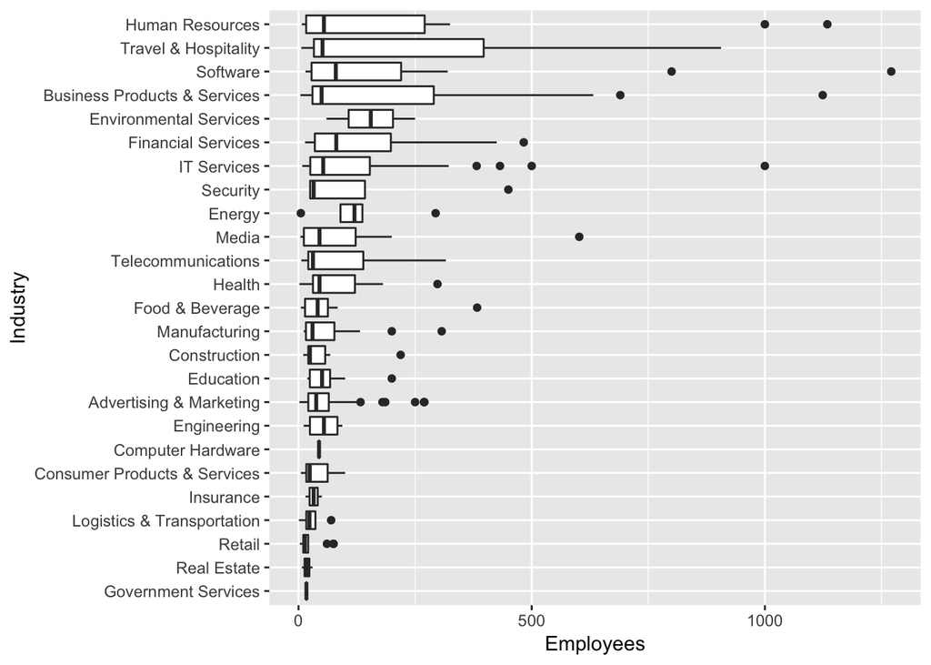

```r
#remove outliers
ny_norm = ny %>%
  filter(Employees <= 2000)


#explore NY state jobs
y <- ggplot(ny_norm, aes(reorder(Industry, Employees, mean), Employees))
y <- y + geom_boxplot() + coord_flip() + labs(x = "Industry", y = "Employees")
y
```

## Question 3

Now imagine you work for an investor and want to see which industries generate the most revenue per employee. Create a chart that makes this information clear. Once again, the distribution per industry should be shown.

[figure not shown]

```r
# Answer Question 3 here

#filter by industry and calculate revenue per employee
industry <- inc %>%
  group_by(Industry) %>%
  summarise(Revenue=sum(Revenue), Employees=sum(Employees)) %>%
  mutate(AvgRev = Revenue/Employees)

z <- ggplot(industry, aes(x=reorder(Industry, AvgRev), y=AvgRev))
z + geom_bar(stat="identity") + coord_flip() + labs(x = "Industry", y = "Number of Employees")
```

We can see here that computer hardware has the highest rate of revenue per employee.